# Nobel Laureates Analysis

We have all heard about the Nobel Prize. The Nobel Prize is a set of annual international awards bestowed in several categories by Swedish and Norwegian institutions in recognition of academic, cultural, or scientific advances.

[figure not shown]

A bit of history…

Alfred Nobel was born on 21 October 1833 in Stockholm, into a family of engineers. He was a chemist, engineer, and inventor. In 1894, Nobel purchased an iron and steel mill, which he made into a major armaments manufacturer. Nobel amassed a fortune during his lifetime, with most of his wealth coming from his 355 inventions, of which dynamite is the most famous.

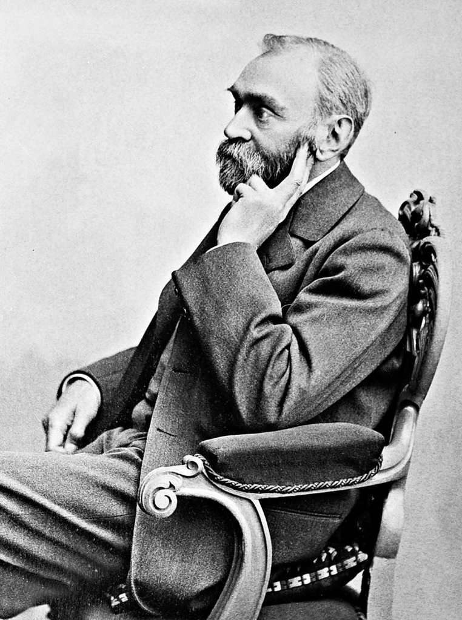

In 1888, his brother Ludvig died, but a French newspaper mistakenly ran an obit for Alfred titled, “The merchant of death is dead.” This caused Alfred to suffer such a crisis of conscience, he created a series of awards to honor those who confer the “greatest benefit on mankind” in physics, chemistry, physiology or medicine, literature and peace. The Nobel Memorial Prize in Economic Sciences was added in 1968 in memory of Alfred Nobel.

**1901 - 2018**

Between 1901 and 2018, the Nobel Prizes and the Prize in Economic Sciences were awarded 590 times to 935 people and organizations. Each Prize consists of a medal, a personal diploma, and a cash award. A lot of Nobel recipients are well known for their accomplishments. Some of the most famous laureates include:  
**Marie Curie**: Chemistry Nobel prize (1911) for the discovery of the elements radium and polonium  
**Albert Einstein**:Physics Nobel prize (1922) for his contribution in theoretical physics  
**Ernest Hemingway**: Literature Nobel prize (1954) for his mastery of the art of narrative  
**Sir Alexander Fleming**: Medicine Nobel prize (1945) for the discovery of penicillin  
**John Nash**: Economics Nobel prize (1994) for his pioneering analysis of equilibria in game theory  
**Mother Terese**: Peace Nobel prize (1979) for founding of the Charity of Missionaries

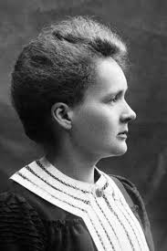

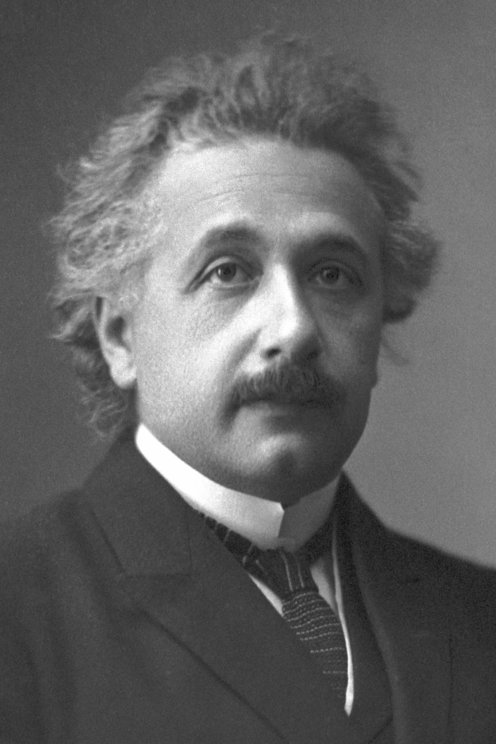

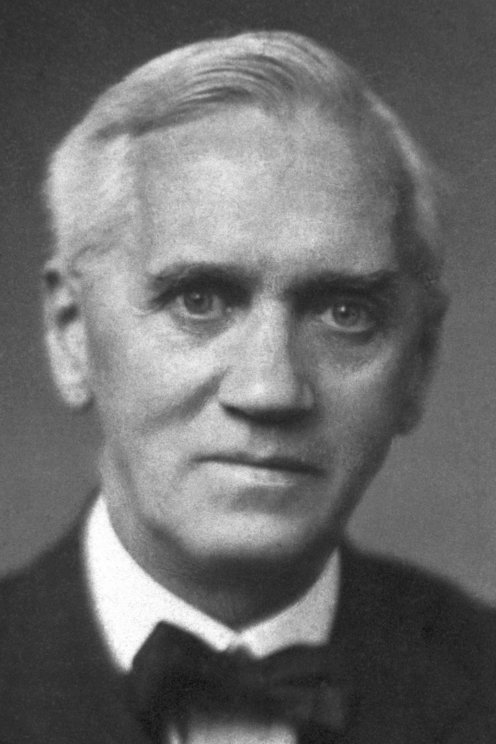

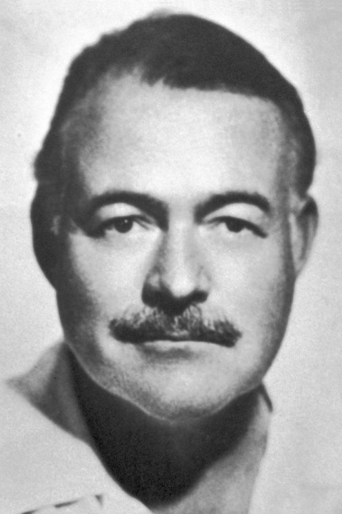

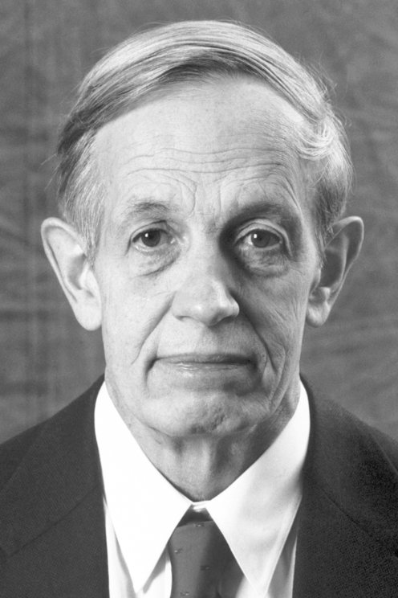

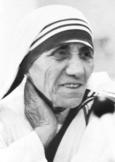

Some famous acceptance speeches for the Nobel Peace Prize

[interactive chart not shown]

Let’s begin…  
Let’s explore the laureates and understand a few more things about the prizes and the people that won them. We have the dataset that includes all the prizes that have been won between 1901 and 2018. In order, to explore the data set we first have to see what type of information is in it. We have already uploaded the data set and created a data dictionary that includes all the heading of the dataset.

[figure not shown]

| Feature | Definition |
| --- | --- |
| ID | Unique id assigned to an individual or an organization |
| agePrizeReceived | Age at which the individual received the prize |
| bornCity | City of birth |
| bornCountry | Country of birth |
| category | Physics, Chemistry, Medicine, Peace, Literature, Economics |
| fullname | Name of the individual and organizations that won the prize |
| gender | Male, Female |
| imageURL | URL to the image of the individual or organisation |
| Laureate Type | Individual or Organisation |
| motivation | The work for which the prize was awarded |
| prizeyear | The year in which the prize was awarded |
| prizeyearcategory | Combination of the prizeYear and Category |

Exploratory Analytics

We have now have read our data set, looked into the data dictionary and know a few more things on the laureates’ features. In order to answer our main question we have to start exploring our dataset by answering some more basic questions.  
Let’s start exploring the data with basic questions around WHAT, WHEN, WHO and WHERE!

WHAT?

Let us look at the total number of prizes awarded. We know that a prize for a category could be shared by maximum three individuals. So we can’t just count the total rows in the dataset to get the answer. We are interested in the combination of the prize year and the category, and luckily we have such a field(prizeYearCategory) directly available in the dataset.

[interactive chart not shown]

Similarly you could create separate card visual for:  
- The number of years the prize was awarded, by choosing the variable year.  
- The number of individuals who won the prize  
- The number of organizations that won the prize

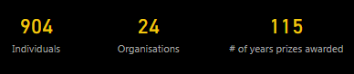

Note: There could be individuals and organizations who won the prize more than once. We will find which of them got more than one prize later, but for now remember we are interested in showing the unique number of individuals and organizations. Clue: You need to use count(distinct) and also use Visual level filter. Check out the video!

[interactive chart not shown]

You could also change a visual. Let us say, instead of the card visual we want to see in a bar graph the count of both the individuals and the organizations.

[interactive chart not shown]

Prizes awarded per category Let us look at the prizes awarded per category. We want to visualize the number of prizes per category, a bar chart would be ideal for this.

[interactive chart not shown]

WHEN?

Let us also visualize the prize distribution over the years. We see some years(1940, 1941 and 1942) during the second world war, that there were no prizes awarded. We also see an increasingly that the prizes are being shared (awarded per category to more individuals).  
And if we look at the bar chart for prizes per category, we see that economics has the lowest number. Let us see if we can find an explanation for it. Click on the bar for economics in the bar graph, we notice that it highlights prizes related to economics in the column chart. This shows the nice visual interaction that is possible in Power BI. From this we see clearly that the prize for economics started only from 1969 onwards, which explains why we have such a low number.

[interactive chart not shown]

WHO?  
How many females won the prize? We could answer this by creating a bar chart (refer to the video-4 for example), with gender as axis and the ‘count of id’ as value. Please remember to include filter to select only individuals.  
Does the gender distribution vary over the various prize categories? Let us create a bar chart with category(exactly same as in video-4) and then have the field gender in the legend. We see that the distribution of women is quite low in Economics, followed by Physics. Would be interesting to see the percentage, for which we could use the 100% stacked bar chart visual.

[interactive chart not shown]

**What is the minimum and the maximum age of the recipients per category?**  
We want to have a table with the minimum and maximum age listed per category. We have a visual called Table that could be used for this.

[interactive chart not shown]

**Who got more than one prizes?**  
We noticed earlier from the distinct count of individuals and organizations that there are some who got more than one prize. Let us have a look to see who they are. Again a table visual would be best fit for this. We are interested in the names of the individual / organization, along with the total number of prizes they won. We filter the visual where the count of prize year is more than one.

[interactive chart not shown]

WHERE?  
So far we have seen interesting information on the number of prizes, per category, who won it etc., let us now find which country has the most number of laureates. We will first visualize this in a bar chart (follow video-4), and later in a map (follow video-9) plotting the country of birth. If we hover our mouse over a particular bubble, it would be nice to see some information on the recipients. We can use the ‘tool tip’ for this and information such as name, prize category, prize year. Now let us build a nice table with the name of the recipients, photo, city of birth, prize category, year and motivation.

Now when we select a country we see the table contents automatically filtered and shows the list of recipients from that country. Same way, we can also select a point in the map to see only that particular person in the table.

[interactive chart not shown]

**How do I make a dashboard?**

[figure not shown]

This is the end of the hands-on exercise.  
We hope you enjoyed it and learned some useful skills!

[figure not shown]